# African Crises Analysis

Gelsomina Pagliaro, Gabriele Tirrito

2023-09-16

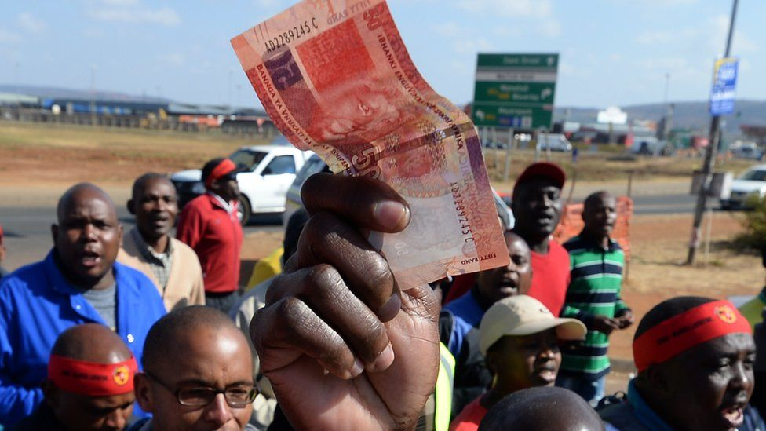

Import dataset

```r
african_data <- read.csv("/Users/pinella/Desktop/africa_files/african_crises.csv")
```

## Exploratory data analysis

```r
cat("African_crisis dataset has", nrow(african_data), "rows, and", ncol(african_data), "columns\n")
```

```
## African_crisis dataset has 1059 rows, and 14 columns
```

```r
cat("Column names are:\n",colnames(african_data))
```

```
## Column names are:
##  case cc3 country year systemic_crisis exch_usd domestic_debt_in_default sovereign_external_debt_default gdp_weighted_default inflation_annual_cpi independence currency_crises inflation_crises banking_crisis
```

Variables i) systemic_crisis : “0” means that no systemic crisis occurred in the year and “1” means that a systemic crisis occurred in the year.

2. exch_usd : The exchange rate of the country vis-a-vis the USD.
3. domestic_debt_in_default : “0” means that no sovereign domestic debt default occurred in the year and “1” means that a sovereign domestic debt default occurred in the year.
4. sovereign_external_debt_default : “0” means that no sovereign external debt default occurred in the year and “1” means that a sovereign external debt default occurred in the year.
5. gdp_weighted_default : The total debt in default vis-a-vis the GDP.
6. inflation_annual_cpi : The annual CPI Inflation rate.
7. independence : “0” means “no independence” and “1” means “independence”.
8. currency_crises : “0” means that no currency crisis occurred in the year and “1” means that a currency crisis occurred in the year.
9. inflation_crises : “0” means that no inflation crisis occurred in the year and “1” means that an inflation crisis occurred in the year.
10. banking_crisis : “no_crisis” means that no banking crisis occurred in the year and “crisis” means that a banking crisis occurred in the year.

##Type of crises

Systemic Crisis: Systemic crisis is a domino effect in which a financial trouble spreads. between institutions and markets until it affects the whole monetary and financial system with dire global economic consequences.

Currency Crisis: A currency crisis is a situation in which serious doubt exists as to whether a country’s central bank has sufficient foreign exchange reserves to maintain the country’s fixed exchange rate. The crisis is often accompanied by a speculative attack in the foreign exchange market. A currency crisis results from chronic balance of payments deficits, and thus is also called a balance of payments crisis. Often such a crisis culminates in a devaluation of the currency.

Inflation Crisis: Inflation is a quantitative measure of the rate at which the average price level of a basket of selected goods and services in an economy increases over a period of time. It is the constant rise in the general level of prices where a unit of currency buys less than it did in prior periods.

Banking Crisis: A banking crisis is often associated with financial crisis. It refers to a panic or a bank run during which investors sell off assets or withdraw money from savings accounts because they fear that the value of those assets will drop if they remain in a financial institution.

```r
african_data[['country']] <- as.factor(african_data[['country']])
african_data[['cc3']] <- as.factor(african_data[['cc3']])
african_data[['case']] <- as.factor(african_data[['case']])

# Rename columns
colnames(african_data)[colnames(african_data) == 'inflation_crises'] <- 'inflation_crisis'
colnames(african_data)[colnames(african_data) == 'currency_crises'] <- 'currency_crisis'

# Introduce boolean categorization for banking_crisis
african_data$banking_crisis <- ifelse(african_data$banking_crisis == "crisis", 1, 0)

# Correct erroneous input for currency_crisis
african_data$currency_crisis[african_data$currency_crisis == 2] <- 1

summary(african_data)
```

```
##       case          cc3              country         year
##  19     :155   EGY    :155   Egypt       :155   Min.   :1860
##  56     :114   ZAF    :114   South Africa:114   1st Qu.:1951
##  70     : 90   ZWE    : 90   Zimbabwe    : 90   Median :1973
##  1      : 85   DZA    : 85   Algeria     : 85   Mean   :1968
##  2      : 77   AGO    : 77   Angola      : 77   3rd Qu.:1994
##  40     : 75   MAR    : 75   Morocco     : 75   Max.   :2014
##  (Other):463   (Other):463   (Other)     :463
##  systemic_crisis      exch_usd        domestic_debt_in_default
##  Min.   :0.00000   Min.   :  0.0000   Min.   :0.00000
##  1st Qu.:0.00000   1st Qu.:  0.1954   1st Qu.:0.00000
##  Median :0.00000   Median :  0.8684   Median :0.00000
##  Mean   :0.07743   Mean   : 43.1408   Mean   :0.03966
##  3rd Qu.:0.00000   3rd Qu.:  8.4628   3rd Qu.:0.00000
##  Max.   :1.00000   Max.   :744.3061   Max.   :1.00000
##
##  sovereign_external_debt_default gdp_weighted_default inflation_annual_cpi
##  Min.   :0.000                   Min.   :0.000000     Min.   :     -29
##  1st Qu.:0.000                   1st Qu.:0.000000     1st Qu.:       2
##  Median :0.000                   Median :0.000000     Median :       6
##  Mean   :0.153                   Mean   :0.006402     Mean   :   20849
##  3rd Qu.:0.000                   3rd Qu.:0.000000     3rd Qu.:      12
##  Max.   :1.000                   Max.   :0.400000     Max.   :21989695
##
##   independence    currency_crisis  inflation_crisis banking_crisis
##  Min.   :0.0000   Min.   :0.0000   Min.   :0.0000   Min.   :0.00000
##  1st Qu.:1.0000   1st Qu.:0.0000   1st Qu.:0.0000   1st Qu.:0.00000
##  Median :1.0000   Median :0.0000   Median :0.0000   Median :0.00000
##  Mean   :0.7762   Mean   :0.1284   Mean   :0.1294   Mean   :0.08876
##  3rd Qu.:1.0000   3rd Qu.:0.0000   3rd Qu.:0.0000   3rd Qu.:0.00000
##  Max.   :1.0000   Max.   :1.0000   Max.   :1.0000   Max.   :1.00000
##
```

Two column names are standardized: ‘inflation_crises’ is renamed to ‘inflation_crisis,’ and ‘currency_crises’ is renamed to ‘currency_crisis.’

The ‘banking_crisis’ column is transformed into a binary variable, where ‘crisis’ is converted to 1, and other values are converted to 0.

Erroneous values (2) in the ‘currency_crisis’ column are corrected to 1.

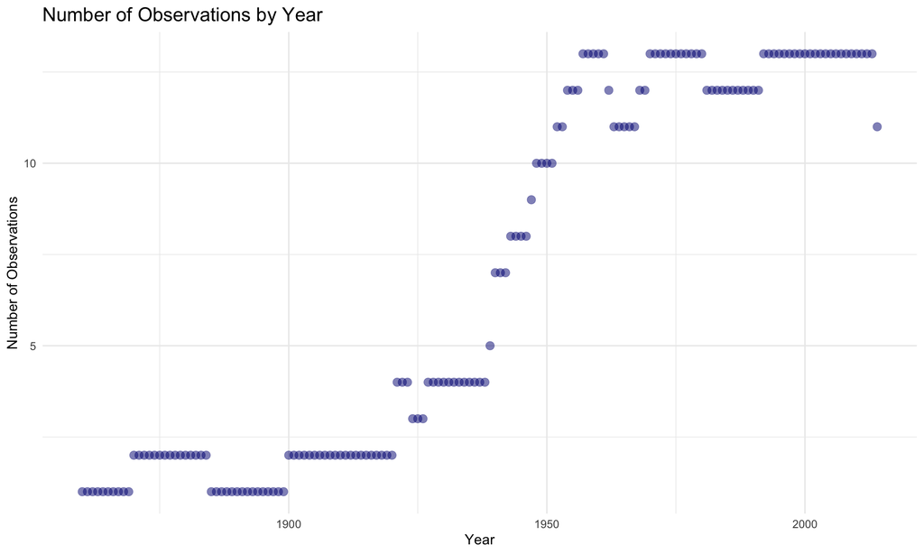

```r
# Calculate the count of observations for each year
library(ggplot2)
year_counts <- table(african_data$year)

# Create a scatter plot for the number of observations by year
p <- ggplot(data = as.data.frame(year_counts), aes(x = as.numeric(names(year_counts)), y = Freq)) +
  geom_point(alpha = 0.5, color = "navy", size = 3, stroke = 0.2) +
  labs(x = "Year", y = "Number of Observations") +
  ggtitle("Number of Observations by Year") + # Set x-axis breaks to years
  theme_minimal() +
  theme(plot.title = element_text(size = 15))

# Print the scatter plot
print(p)
```

By examining this plot, it becomes evident that the dataset exhibits a notably limited number of observations prior to 1925, with the majority of observations being recorded after the year 1950. Nevertheless, the primary aim of this project is to elucidate the relationship between systemic crises in Africa and specific contextual conditions. Consequently, we will retain these earlier observations to enhance our understanding of how various variables within the dataset coincide with systemic crises, which is the focal point of our analysis.

```r
missing_counts <- colSums(is.na(african_data))
print(missing_counts)
```

```
##                            case                             cc3
##                               0                               0
##                         country                            year
##                               0                               0
##                 systemic_crisis                        exch_usd
##                               0                               0
##        domestic_debt_in_default sovereign_external_debt_default
##                               0                               0
##            gdp_weighted_default            inflation_annual_cpi
##                               0                               0
##                    independence                 currency_crisis
##                               0                               0
##                inflation_crisis                  banking_crisis
##                               0                               0
```

The dataset is devoid of any missing values, ensuring that all data points are complete and available for analysis.

## Project objective overview

```r
library(dplyr)
```

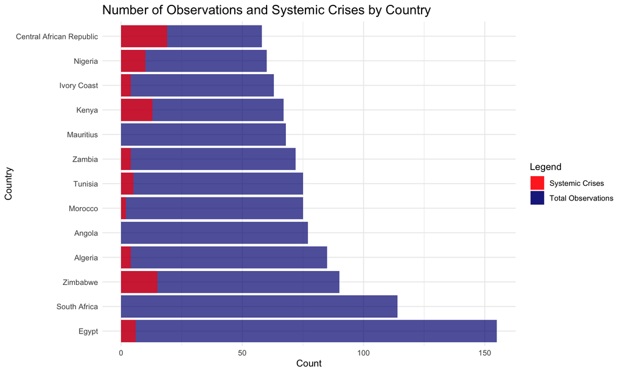

```r
# Calculate the count of observations for each country and the count of systemic crises
country_counts <- african_data %>%
  group_by(country) %>%
  summarize(total_count = n(),
            systemic_crises_count = sum(systemic_crisis))

# Create a bar plot for the number of observations and systemic crises per country
p <- ggplot(data = country_counts, aes(x = reorder(country, -total_count), y = total_count)) +
  geom_bar(stat = "identity", aes(fill = "Total Observations"), alpha = 0.7) +
  geom_bar(stat = "identity", aes(x = country, y = systemic_crises_count, fill = "Systemic Crises"), alpha = 0.7) +
  labs(x = "Country", y = "Count", fill = "Legend") +
  ggtitle("Number of Observations and Systemic Crises by Country") +
  scale_fill_manual(values = c("Total Observations" = "navy", "Systemic Crises" = "red")) +
  coord_flip() +  # Flip x and y axes for horizontal bars
  theme_minimal() +
  theme(plot.title = element_text(size = 15))

# Print the barplot
print(p)
```

In the dataset, we can observe the number of observations for each country and the proportion of observations in which a systemic crisis occurred. Notably, the count of observations is fairly consistent across most countries, with the exceptions of Egypt and South Africa, which have an unusually high number of observations, exceeding 100.

When examining the count of systemic crises, it becomes apparent that certain countries, such as the Central African Republic, Nigeria, Kenya, and Zimbabwe, consistently experienced systemic crises across a substantial portion of the observations.

The presence of systemic crises in these countries may be attributed to a variety of factors, including economic vulnerabilities, political instability, or external shocks. Further analysis and contextual information would be needed to gain a deeper understanding of why these specific countries faced such challenges over the observed period. Factors such as government policies, economic conditions, geopolitical influences, and historical events could have contributed to the observed systemic crises in these nations.

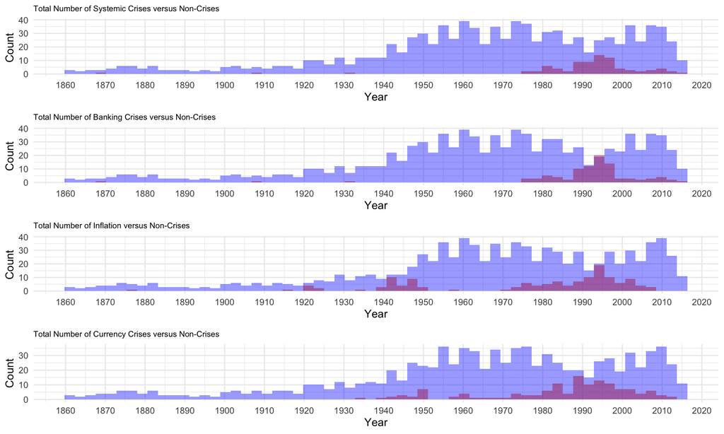

```r
# Load the required libraries
library(ggplot2)
library(cowplot)

# Create a histogram plot for systemic crises and banking crises
p_systemic <- ggplot(african_data, aes(x = year)) +
  geom_histogram(data = subset(african_data, systemic_crisis == 0), fill = "blue", alpha = 0.4, bins = 60) +
  geom_histogram(data = subset(african_data, systemic_crisis == 1), fill = "maroon", alpha = 0.5, bins = 60) +
  scale_x_continuous(breaks = seq(1860, 2020, by = 10)) +
  labs(x = "Year", y = "Count") +
  ggtitle("Total Number of Systemic Crises versus Non-Crises") +
  theme_minimal() +
  theme(plot.title = element_text(size = 8)) +
  guides(fill = guide_legend(title = NULL))

p_banking <- ggplot(african_data, aes(x = year)) +
  geom_histogram(data = subset(african_data, banking_crisis == 0), fill = "blue", alpha = 0.4, bins = 60) +
  geom_histogram(data = subset(african_data, banking_crisis == 1), fill = "maroon", alpha = 0.5, bins = 60) +
  scale_x_continuous(breaks = seq(1860, 2020, by = 10)) +
  labs(x = "Year", y = "Count") +
  ggtitle("Total Number of Banking Crises versus Non-Crises") +
  theme_minimal() +
  theme(plot.title = element_text(size = 8)) +
  guides(fill = guide_legend(title = NULL))

p_currency <- ggplot(african_data, aes(x = year)) +
  geom_histogram(data = subset(african_data, currency_crisis == 0), fill = "blue", alpha = 0.4, bins = 60) +
  geom_histogram(data = subset(african_data, currency_crisis == 1), fill = "maroon", alpha = 0.5, bins = 60) +
  scale_x_continuous(breaks = seq(1860, 2020, by = 10)) +
  labs(x = "Year", y = "Count") +
  ggtitle("Total Number of Currency Crises versus Non-Crises") +
  theme_minimal() +
  theme(plot.title = element_text(size = 8)) +
  guides(fill = guide_legend(title = NULL))

p_inflation <- ggplot(african_data, aes(x = year)) +
  geom_histogram(data = subset(african_data, inflation_crisis == 0), fill = "blue", alpha = 0.4, bins = 60) +
  geom_histogram(data = subset(african_data, inflation_crisis == 1), fill = "maroon", alpha = 0.5, bins = 60) +
  scale_x_continuous(breaks = seq(1860, 2020, by = 10)) +
  labs(x = "Year", y = "Count") +
  ggtitle("Total Number of Inflation versus Non-Crises") +
  theme_minimal() +
  theme(plot.title = element_text(size = 8)) +
  guides(fill = guide_legend(title = NULL))

# Arrange the plots vertically
p_combined <- plot_grid(p_systemic, p_banking, p_inflation, p_currency, ncol = 1)

# Print the combined plot
print(p_combined)
```

The plots presented above offer a visual representation of crisis counts for each year, juxtaposing the count of crises with the count of non-crises. This visual display provides valuable insight into not only the overall number of observations but also the proportion of instances where a crisis occurred relative to those where it did not.

A series of plots are provided for different types of crises, including systemic, banking, currency, and inflation crises. An interesting observation emerges from these plots: the vast majority of crises across all these categories, as recorded in the dataset, concentrated within the time span between 1970 and 2010.

The question of why such a tumultuous period occurred in Africa between 1970 and 2010 is multifaceted and may be attributed to various complex factors. Potential factors contributing to this tumult include economic challenges, political instability, civil conflicts, external pressures, and global economic fluctuations.

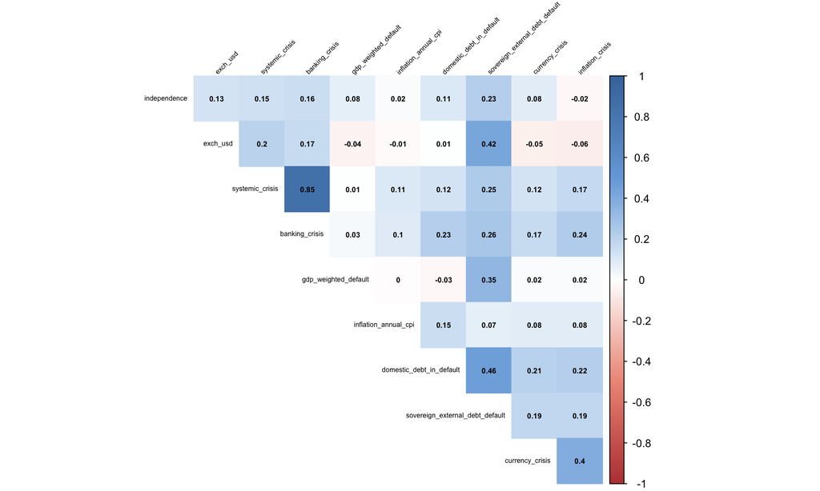

```r
library(corrplot)
M<-cor(african_data[, c("systemic_crisis","exch_usd","domestic_debt_in_default","sovereign_external_debt_default","gdp_weighted_default","inflation_annual_cpi","independence", "currency_crisis","inflation_crisis","banking_crisis")])

col <- colorRampPalette(c("#BB4444", "#EE9988", "#FFFFFF", "#77AADD", "#4477AA"))
corrplot(M, method="color", col=col(200),
         type="upper", order="hclust",
         addCoef.col = "black", # Add coefficient of correlation
         tl.col="black", tl.srt=45, #Text label color and rotation
         tl.cex=0.5,
         number.cex = 0.55,
         # hide correlation coefficient on the principal diagonal
         diag=FALSE
         )
```

#Exchange rate

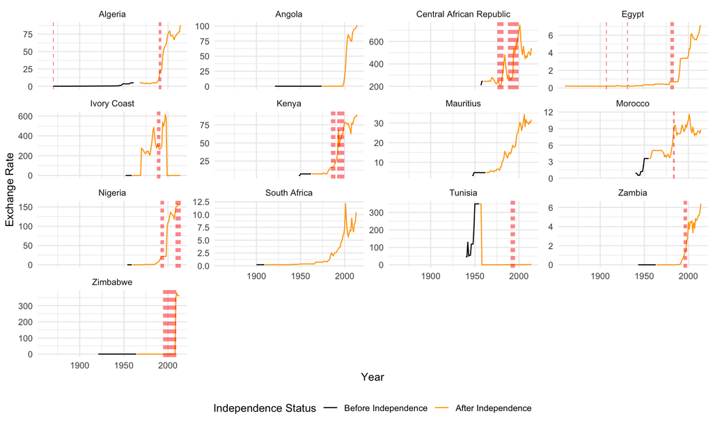

```r
p <- ggplot(african_data, aes(x = year, y = exch_usd, color = as.factor(independence))) +
  geom_line() +
  labs(x = "Year", y = "Exchange Rate", color = "Independence Status") +  # Set the color legend title
  theme_minimal() +
  theme(legend.position = "bottom") +  # Move legend to the bottom
  facet_wrap(~ country, ncol = 4, scales = "free_y") +
  scale_color_manual(values = c("0" = "black", "1" = "orange"), labels = c("Before Independence", "After Independence"))

p <- p +
  geom_vline(data = subset(african_data, systemic_crisis == 1), aes(xintercept = year), color = "red", linetype = "dashed", size =0.2)
print(p)
```

The primary objective of the plot is twofold: firstly, it seeks to illustrate the occurrence of systemic crises, and secondly, it aims to depict the dynamics of the local currency exchange rates in relation to the timeline of African independence.

However, a notable challenge arises when examining the effects of independence on systemic crises. The reason for this challenge is the limited availability of observations prior to the attainment of independence. As a result, there is insufficient data to draw meaningful conclusions regarding the impact of independence on systemic crises.

It’s essential to understand that the occurrence of a systemic crisis is often closely intertwined with significant fluctuations in the local currency exchange rates. A marked depreciation of the local currency can act as a catalyst for the emergence of systemic crises. In this context, the exchange rate becomes a crucial factor that contributes to the likelihood of systemic crises occurring.

In simpler terms, when the local currency experiences a substantial decline in its value, it can trigger economic instability, financial vulnerabilities, and, subsequently, systemic crises. This underscores the importance of monitoring and understanding the dynamics of exchange rates in the context of systemic crisis analysis.

However, due to the data limitations before independence, a comprehensive assessment of how independence specifically impacted these dynamics may be challenging. Nonetheless, analyzing the available data on systemic crises and exchange rate fluctuations can still provide valuable insights into their interplay within the given timeframe.

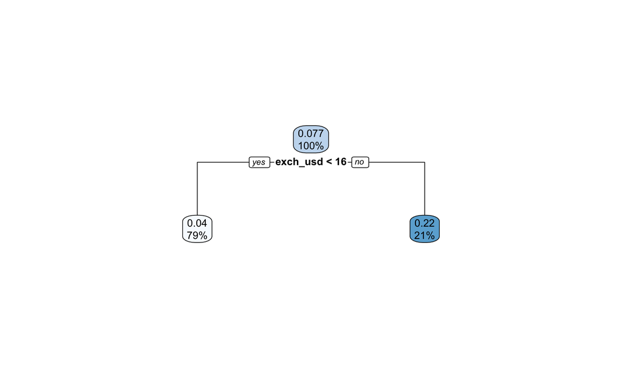

```r
library(rpart)
library(rpart.plot)

tree_model <- rpart(systemic_crisis ~ inflation_annual_cpi+independence+exch_usd, african_data)

pruned_tree_model <- prune(tree_model, cp = 0.04)

# Display the pruned tree's number of leaf nodes
rpart.plot(pruned_tree_model)
```

The decision tree has identified an exchange rate (exch_rate) threshold at 16 units of the local currency per 1 USD. This threshold is used to separate the data into two groups: one group with exchange rates less than 16 and another group with exchange rates greater than or equal to 16.

Economic Implications: Economically, this threshold implies that the exchange rate value of 16 serves as a critical point for predicting the likelihood of a systemic crisis:

Exchange Rate < 16: When the exchange rate is less than 16, it suggests a higher likelihood of not experiencing a systemic crisis within the dataset. This may indicate a stronger or more stable local currency relative to the USD.

Exchange Rate ≥ 16: When the exchange rate is greater than or equal to 16, it suggests a higher likelihood of experiencing a systemic crisis within the dataset. This may indicate a weaker or less stable local currency relative to the USD.

#Inflation Rate

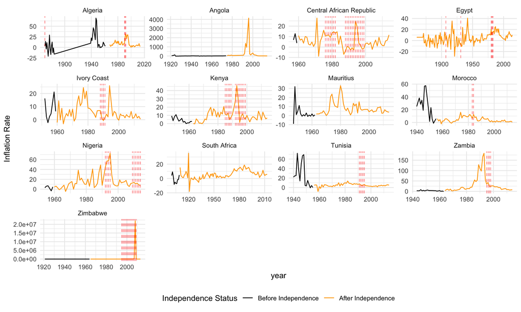

```r
# Create the plot
p <- ggplot(african_data, aes(x = year, y = inflation_annual_cpi, color = as.factor(independence))) +
  geom_line() +
  labs(y = "Inflation Rate", color = "Independence Status") +
  theme_minimal() +
  theme(legend.position = "bottom") +
  facet_wrap(~ country, ncol = 4, scales = "free") +
  scale_color_manual(values = c("0" = "black", "1" = "orange"), labels = c("Before Independence", "After Independence"))

# Add vertical lines for systemic crises
p <- p +
  geom_vline(data = subset(african_data, systemic_crisis == 1), aes(xintercept = year), color = "red", linetype = "dashed", size = 0.2)

# Print the plot
print(p)
```

It’s pivotal to acknowledge that systemic crises often coincide with significant fluctuations in the inflation rate. A high or rapidly rising inflation rate can serve as a catalyst for systemic crises. Consequently, the inflation rate emerges as a pivotal factor that shapes the likelihood of systemic crises.

In simpler terms, when an economy experiences a substantial inflationary surge, it sets in motion a chain reaction characterized by economic instability, financial vulnerabilities, and the eventual emergence of systemic crises. This underscores the critical importance of closely monitoring and comprehending inflation rate trends within the broader context of systemic crisis analysis.

#Co-occurrence of Crises

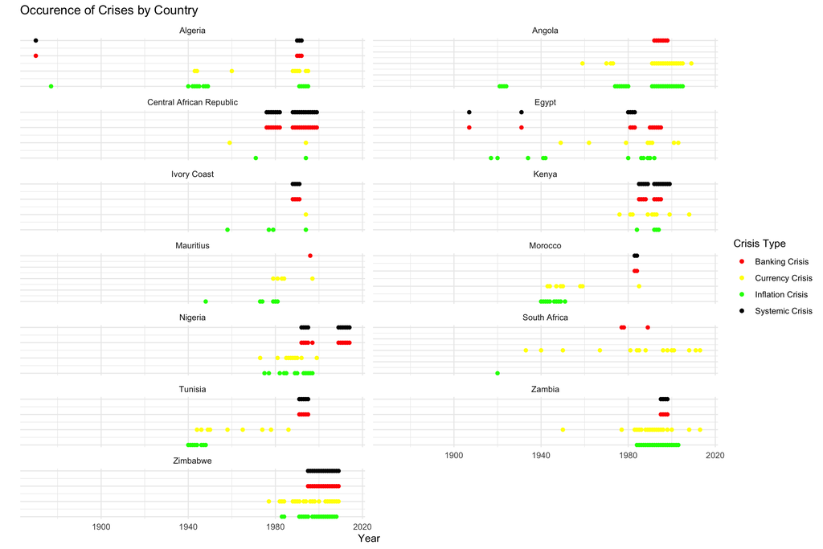

```r
# Define custom colors
crisis_colors <- c('Inflation Crisis' = 'green', 'Currency Crisis' = 'yellow', 'Banking Crisis' = 'red', 'Systemic Crisis' = 'black')

# Create scatterplots with facets for each country
p <- ggplot(african_data, aes(x = year)) +
  geom_point(data = african_data[african_data$inflation_crisis == 1, ], aes(y = inflation_crisis, color = 'Inflation Crisis'), show.legend = TRUE) +
  geom_point(data = african_data[african_data$currency_crisis == 1, ], aes(y = currency_crisis+1, color = 'Currency Crisis'), show.legend = TRUE) +
  geom_point(data = african_data[african_data$banking_crisis == 1, ], aes(y = banking_crisis+2, color = 'Banking Crisis'), show.legend = TRUE) +
  geom_point(data = african_data[african_data$systemic_crisis == 1, ], aes(y = systemic_crisis+3, color = 'Systemic Crisis'), show.legend = TRUE) +
  facet_wrap(~ country, ncol = 2, scales = "free_y") +
  labs(x = "Year", y = "") +
  scale_color_manual(values = crisis_colors, name = "Crisis Type") +
  ggtitle("Occurence of Crises by Country") +
  theme_minimal() +
  theme(legend.position = "right", axis.text.y = element_blank(), axis.ticks.y = element_blank())  # Remove y-axis numbers and ticks

# Print the scatterplots
print(p)
```

Between 1860 and 2014, all countries except Angola, Mauritius and South Africa were affected by Systemic Crisis. Most affected countries being Central African Republic,Zimbabwe,Kenya and Nigeria.

All countries were affected by Currency Crisis in that period and the most affected countries were Zimbabwe,Zambia,Angola,South Africa.

```r
# Create an empty data frame to store correlation results
cor_lag <- data.frame(matrix(nrow = 10, ncol = 3))

# Loop through column names (assuming these are the column names you want to analyze)
columns_to_analyze <- c("banking_crisis", "currency_crisis", "inflation_crisis")

for (col_name in columns_to_analyze) {
  # Loop through lag periods from 0 to 9
  for (i in 0:9) {
    # Calculate the lagged variable
    ciao <- african_data %>%
      group_by(country) %>%
      mutate(lag_inflation = lag(.data[[col_name]], n = i))

    # Calculate and store the correlation
    col_index <- match(col_name, columns_to_analyze)  # Get the column index
    cor_lag[i + 1, col_index] <- cor(ciao$systemic_crisis, ciao$lag_inflation, use = "complete.obs")
  }
}

colnames(cor_lag) <- columns_to_analyze
cor_lag['lag'] <- 0:9
```

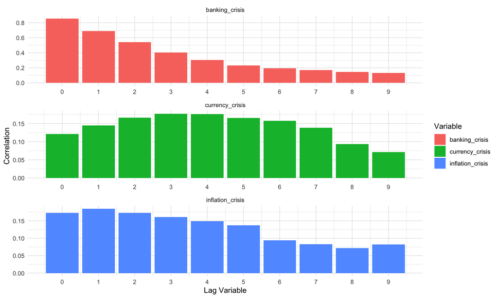

```r
library(ggplot2)
library(dplyr)
library(tidyr)

cor_long <- cor_lag %>%
  pivot_longer(cols = -lag, names_to = "Variable", values_to = "Correlation")

ggplot(cor_long, aes(x = lag, y = Correlation, fill = Variable)) +
  geom_bar(stat = "identity") +
  labs(x = "Lag Variable", y = "Correlation") +
  facet_wrap(~ Variable, scales = "free", ncol = 1) +
  scale_x_continuous(breaks = 0:9, labels = 0:9) +  # Set custom breaks and labels
  theme_minimal()
```

In this graphical representation, each bar signifies the degree of correlation between the variable “systemic crisis” and observations of different types of crises that occurred at previous time points. By examining this plot, we can discern significant patterns in the temporal relationships between systemic crises and other types of crises.

Lastly, when it comes to banking crises, the most substantial correlation is observed at lag 0. This implies an immediate correspondence between systemic crises and banking crises, indicating that these two types of crises tend to occur simultaneously.

```r
library(knitr)
library(lmtest)
# Perform Granger causality tests for multiple variables
granger_test_result_banking <- grangertest(african_data$systemic_crisis ~ african_data$banking_crisis, order = 1)
granger_test_result_currency <- grangertest(african_data$systemic_crisis ~ african_data$currency_crisis, order = 3)
granger_test_result_inflation <- grangertest(african_data$systemic_crisis ~ african_data$inflation_crisis, order = 1)
library(tableHTML)

granger_test_result_banking
```

```
## Granger causality test
##
## Model 1: african_data$systemic_crisis ~ Lags(african_data$systemic_crisis, 1:1) + Lags(african_data$banking_crisis, 1:1)
## Model 2: african_data$systemic_crisis ~ Lags(african_data$systemic_crisis, 1:1)
##   Res.Df Df      F Pr(>F)
## 1   1055
## 2   1056 -1 0.5019 0.4788
```

```r
granger_test_result_currency
```

```
## Granger causality test
##
## Model 1: african_data$systemic_crisis ~ Lags(african_data$systemic_crisis, 1:3) + Lags(african_data$currency_crisis, 1:3)
## Model 2: african_data$systemic_crisis ~ Lags(african_data$systemic_crisis, 1:3)
##   Res.Df Df      F   Pr(>F)
## 1   1049
## 2   1052 -3 3.8965 0.008763 **
## ---
## Signif. codes:  0 '***' 0.001 '**' 0.01 '*' 0.05 '.' 0.1 ' ' 1
```

```r
granger_test_result_inflation
```

```
## Granger causality test
##
## Model 1: african_data$systemic_crisis ~ Lags(african_data$systemic_crisis, 1:1) + Lags(african_data$inflation_crisis, 1:1)
## Model 2: african_data$systemic_crisis ~ Lags(african_data$systemic_crisis, 1:1)
##   Res.Df Df      F   Pr(>F)
## 1   1055
## 2   1056 -1 6.9562 0.008476 **
## ---
## Signif. codes:  0 '***' 0.001 '**' 0.01 '*' 0.05 '.' 0.1 ' ' 1
```

## Classification

According to the the objective of the entire project our target variable, for the classification, is the “systemic crisis” in Africa. Indeed it was meaningful to check for the distribution of the target variable across all the observations.

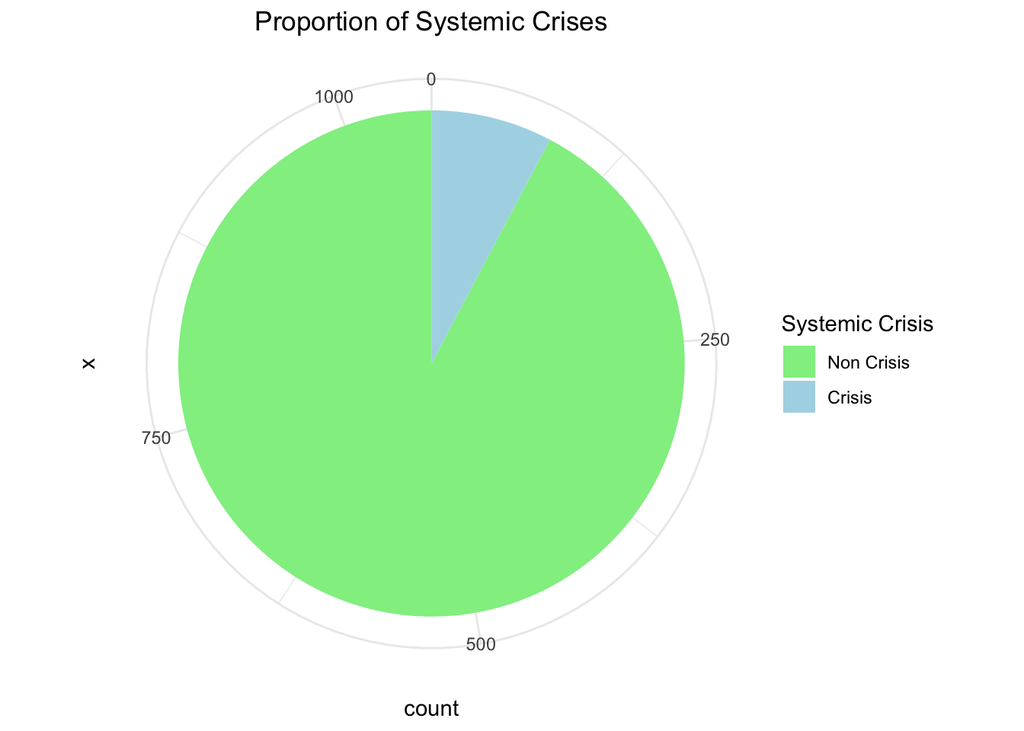

```r
custom_colors <- c("lightgreen", "lightblue")  # Replace with your desired colors

# Create a pie chart with ggplot2
p <- ggplot(african_data, aes(x = "", fill = factor(systemic_crisis, labels = c("Non Crisis", "Crisis")))) +
  geom_bar(width = 1) +
  coord_polar(theta = "y") +  # Convert to polar coordinates
  labs(
    title = "Proportion of Systemic Crises",
    fill = "Systemic Crisis"
  ) +
  theme_minimal() +
  theme(plot.title = element_text(hjust = 0.5)) +
  scale_fill_manual(values = custom_colors)  # Set custom colors

# Print the pie chart
print(p)
```

As observed, the number of occurrences recorded for systemic crises is significantly lower compared to non-crisis events in the dataset. This imbalance in the data distribution can pose challenges when training machine learning classifiers. Classifiers tend to be biased towards the majority class, which, in this case, is the non-crisis category. This imbalance can result in suboptimal model performance and lower accuracy.

To address this issue, an up-sampling method has been employed. Up-sampling aims to balance the class distribution by increasing the number of observations in the minority class, in this case, systemic crises. By doing so, the classifier is provided with a more balanced set of examples from both classes, which can lead to better model generalization and improved predictive accuracy.

```r
library(ROSE)
#pre-processing the dataset in order to apply the oversampling tecnique

df <- african_data[, !names(african_data) %in% c("cc3", "year")]
columns_to_convert <- c("systemic_crisis", "domestic_debt_in_default",
                         "sovereign_external_debt_default", "independence",
                         "currency_crisis", "inflation_crisis")
df <- df[, -which(names(df) == "country")]

# Convert the selected columns to factor format
df[, columns_to_convert] <- lapply(df[, columns_to_convert], as.factor)

resampled_df <- ROSE(systemic_crisis ~ ., data = df, seed = 123)$data
```

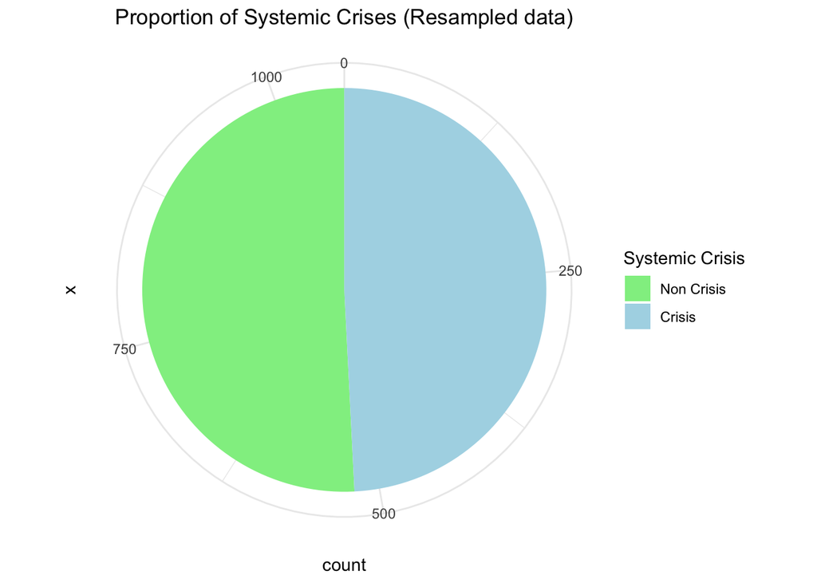

```r
custom_colors <- c("lightgreen", "lightblue")  # Replace with your desired colors

p <- ggplot(resampled_df, aes(x = "", fill = factor(systemic_crisis, labels = c("Non Crisis", "Crisis")))) +
  geom_bar(width = 1) +
  coord_polar(theta = "y") +  # Convert to polar coordinates
  labs(
    title = "Proportion of Systemic Crises (Resampled data)",
    fill = "Systemic Crisis"
  ) +
  theme_minimal() +
  theme(plot.title = element_text(hjust = 0.5)) +
  scale_fill_manual(values = custom_colors)

# Print the pie chart
print(p)
```

resampled classification

```r
library(e1071)
library(caTools)
split <- sample.split(iris, SplitRatio = 0.8)
x_train <- subset(resampled_df, split == "TRUE")
x_test <- subset(resampled_df, split == "FALSE")
y_train <- x_train$systemic_crisis
y_test <- x_test$systemic_crisis
print(nrow(x_train))
```

```
## [1] 847
```

```r
print(nrow(x_test))
```

```
## [1] 212
```

KNN

```r
library(class)
library(caret)
knn_model <- knn(train = x_train, test = x_test, cl = y_train, k = 5)
ypred_knn <- knn_model

# Display precision, recall, and F1-score for each class
confusion_matrix_knn <- confusionMatrix(ypred_knn, y_test)
print(confusion_matrix_knn$table)
```

```
##           Reference
## Prediction   0   1
##          0 107   0
##          1   0 105
```

Random Forest

```r
library(randomForest)
rf_model <- randomForest(x = x_train, y = y_train)
ypred_rf <- predict(rf_model, newdata = x_test)

confusion_matrix_rf <- confusionMatrix(ypred_rf, y_test)
print(confusion_matrix_rf$table)
```

```
##           Reference
## Prediction   0   1
##          0 107   0
##          1   0 105
```

Naive Bayes

```r
library(e1071)
nb_model <- naiveBayes(x = x_train, y = y_train)
ypred_nb <- predict(nb_model, newdata = x_test)

confusion_matrix_nb <- confusionMatrix(ypred_nb, y_test)
print(confusion_matrix_nb$table)
```

```
##           Reference
## Prediction   0   1
##          0 104  11
##          1   3  94
```

SVM

```r
library(class)
library(caret)

svm_model <- svm(systemic_crisis ~ ., data = x_train, kernel = "linear")
ypred_svm <- predict(svm_model, x_test)

confusion_matrix_svm <- confusionMatrix(ypred_svm, y_test)
print(confusion_matrix_svm$table)
```

```
##           Reference
## Prediction   0   1
##          0 105   8
##          1   2  97
```

```r
library(caret)
library(yardstick)
model_names <- c("KNN", "Random Forest", "Naive Bayes", "SVM")
predictions =  list(ypred_knn, ypred_rf, ypred_nb, ypred_svm)

evaluation_table <- function(model_names, predictions, y_test){

  num_models <- length(predictions)

  Precision <- numeric(num_models)
  Recall <- numeric(num_models)
  F1_Score <- numeric(num_models)
  Accuracy <- numeric(num_models)

  for (i in 1:num_models){
  model <- model_names[[i]]
  prediction <- predictions[[i]]

  TP <- sum(prediction == 1 & y_test == 1)
  FN <- sum(prediction == 0 & y_test == 1)
  FP <- sum(prediction == 1 & y_test == 0)
  TN <- sum(prediction == 0 & y_test == 0)

  Precision[i] <- TP / (TP + FP)
  Recall[i] <- TP / (TP + FN)
  F1_Score[i] <- 2 * (Precision[i] * Recall[i]) / (Precision[i] + Recall[i])
  Accuracy[i] <- (TP + TN) / (TP + TN + FP + FN)

  }
  evaluation_table <- data.frame(
  Model = model_names,
  Precision = Precision,
  Recall = Recall,
  F1_Score = F1_Score,
  Accuracy = Accuracy
)
  return(evaluation_table)
}
```

```r
eval_table <- evaluation_table(model_names, predictions, y_test)
print(eval_table)
```

```
##           Model Precision    Recall  F1_Score  Accuracy
## 1           KNN 1.0000000 1.0000000 1.0000000 1.0000000
## 2 Random Forest 1.0000000 1.0000000 1.0000000 1.0000000
## 3   Naive Bayes 0.9690722 0.8952381 0.9306931 0.9339623
## 4           SVM 0.9797980 0.9238095 0.9509804 0.9528302
```